# Project Python Foundations: FoodHub Data Analysis

# HeatMap Analysis (Cost of the order vs Food Preapration Time vs Delivery Time)

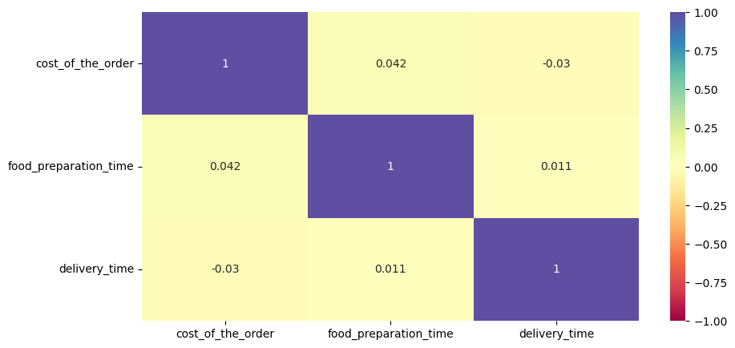

```python
#heat map on the numerical data.
cols = ['cost_of_the_order', 'food_preparation_time', 'delivery_time']
plt.figure(figsize=(10,5))
sns.heatmap(df[cols].corr(),annot=True,cmap='Spectral',vmin=-1,vmax=1)
plt.show()
```

- Looks like there is no positive or negative correlation exists between delivery_time, food_preparation_time and cost_of_the_order.

# Pair Plot (Cost of the order vs Food Preparation time vs Delivery Time)

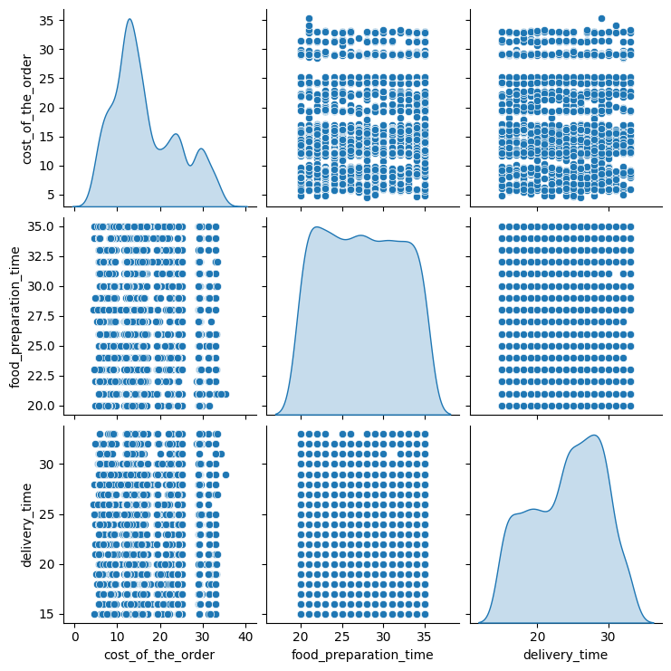

```python
# pair plot on the numerical data to see the correlation.
sns.pairplot(df, vars=['cost_of_the_order', 'food_preparation_time', 'delivery_time'], diag_kind="kde");
```

- Not much correlation present between 'cost_of_the_order', 'food_preparation_time', 'delivery_time' three variables

# Scatter Plot (Cost of the Order vs Rating)

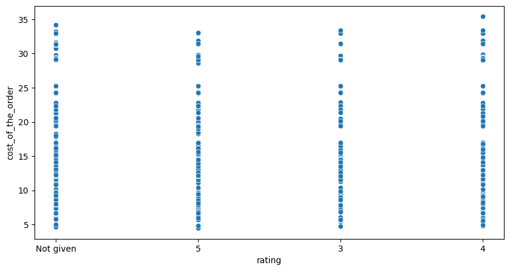

```python
# scatter plot.
plt.figure(figsize=(10,5))
sns.scatterplot(x='rating', y='cost_of_the_order', data=df)
plt.show()
```

- Tried to analyze if there is any correlation between the cost and the customer satisfaction. But From the given data, not able to see any specific correlation.

# Line Plot (Rating vs Delivery Time vs Day of the Week)

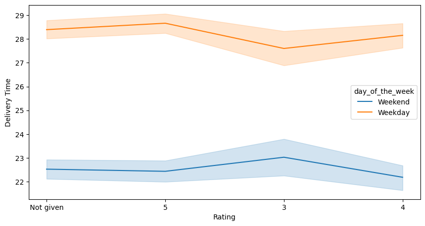

```python
#line plot
plt.figure(figsize=(10,5))
sns.lineplot(x='rating', y='delivery_time', data=df, hue='day_of_the_week')
plt.ylabel("Delivery Time")
plt.xlabel("Rating")
plt.show()
```

# Cusine Type vs Cost of the Order vs Day of the week

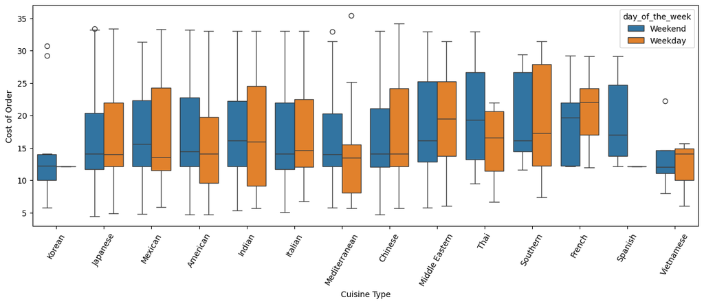

```python
# boxplot the relationship between cuisine type and cost of order
plt.figure(figsize=(15, 5));
sns.boxplot(x='cuisine_type', y="cost_of_the_order", data=df, hue='day_of_the_week');
plt.xticks(rotation=60, size=10);
plt.ylabel('Cost of Order', size=10);
plt.xlabel('Cuisine Type', size=10);
```

- Week day orders on Korean and Spanish are very low compared to week end
- Median cost of orders are higher on weekends for Mexican, American, Indian, Medierranean and Thai.
- Japanese and Chinese median cost of orders are approximately same.
- Median cost of orders are higher on weekdays for Italian, Middle Eastern, Southern, French and Vietnamese.
- There are outlier cost orders for Korean, Japanese, Mediterranean and Vietnamese. In that only Mediterranean has the week day outlier.
- Costliest order is from Mediterranean Restaurant.

# Cusine Type vs Restaurant Count

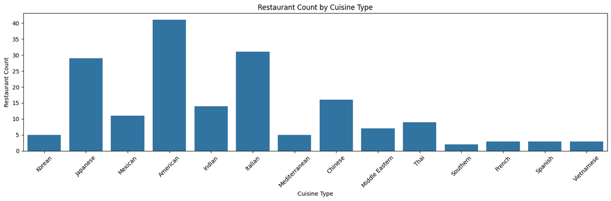

```python
#bar plot between cusine type and restaurant count
plt.figure(figsize=(15, 5));
df['restaurant_count'] = df.groupby('cuisine_type')['restaurant_name'].transform('nunique')
sns.barplot(x='cuisine_type', y='restaurant_count', data=df.drop_duplicates('cuisine_type'))
plt.title('Restaurant Count by Cuisine Type')
plt.xlabel('Cuisine Type')
plt.ylabel('Restaurant Count')
plt.xticks(rotation=45)
plt.tight_layout()
plt.show()
```

- Number of American Restaurants are higher, followed by Italian, Japanese, Chinese and Indian.

# Cuisine Type vs Food Preparation Time vs Delivery Time

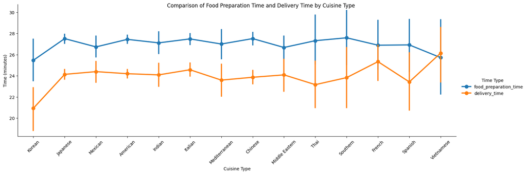

```python
# melt to combine the food preparation time and delivery time.
df_melted = df.melt(id_vars='cuisine_type', value_vars=['food_preparation_time', 'delivery_time'], var_name='Time Type', value_name='Time')

# Create the catplot
g = sns.catplot(
    data=df_melted,
    x='cuisine_type',
    y='Time',
    hue='Time Type',
    kind='point',
    height=5,
    aspect=3
)

# Rotate the x-axis labels for better readability
g.set_xticklabels(rotation=45)

# sub title, labels and show the plot
g.fig.suptitle('Comparison of Food Preparation Time and Delivery Time by Cuisine Type')
g.set_axis_labels('Cuisine Type', 'Time (minutes)')
plt.show()
```

- All cusine types food preparation time is higher than the delivery time except vietnamese.
- As per the confidence intervals, American, Japanese have less variability in data while Thai, Southern and Vietnamese have more variability in data.

# Cusine Type vs Rating

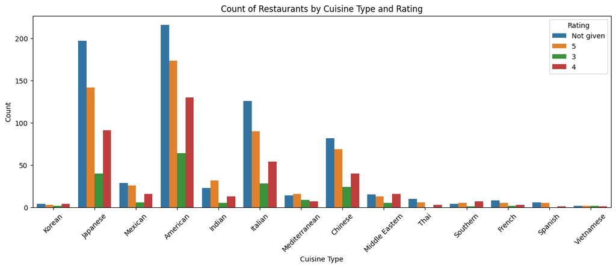

```python
plt.figure(figsize=(15, 5));
sns.countplot(data=df, x='cuisine_type', hue='rating')
# Set the titles and labels
plt.title('Count of Restaurants by Cuisine Type and Rating')
plt.xlabel('Cuisine Type')
plt.ylabel('Count')

# Rotate the x-axis labels for better readability
plt.xticks(rotation=45)
# Display the legend
plt.legend(title='Rating')
# Show the plot
plt.show()
```

- Rating is not correlated with cuisine type and vice versa

# Cost of the order vs Day of the Week vs Rating

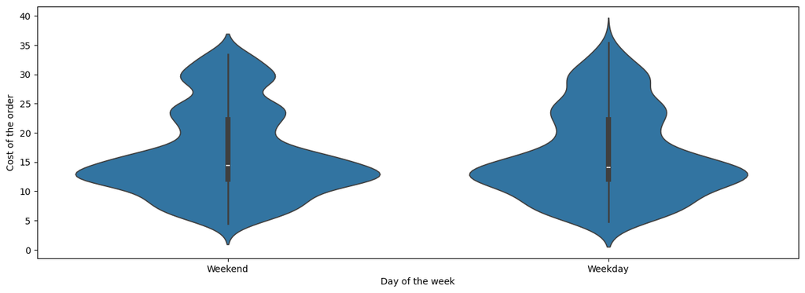

```python
#violin plot
plt.figure(figsize=(15, 5));
sns.violinplot(x='day_of_the_week', y='cost_of_the_order', data=df)
plt.xlabel('Day of the week')
plt.ylabel('Cost of the order')
plt.show()
```

- Median week end cost of order is little higher than median week day cost of order.

# Cost of order vs Delivery Time.

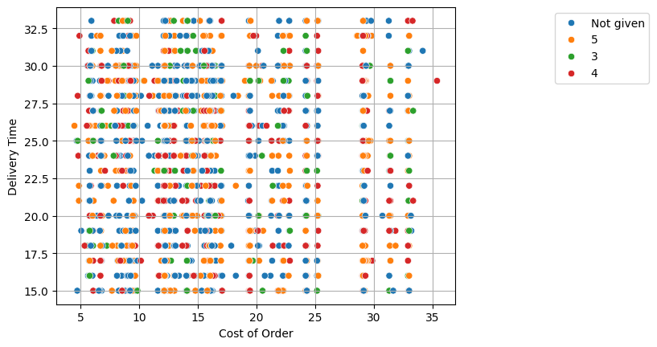

```python
#Scatter plot
sns.scatterplot(data=df, x='cost_of_the_order', y='delivery_time', hue='rating')
plt.xticks(size=10)
plt.ylabel('Delivery Time')
plt.xlabel('Cost of Order')
plt.legend(bbox_to_anchor=(1.5, 1))
plt.grid(True)
plt.show()
```

# Rating vs Delivery Time + Preparation Time (Total Time after Order)

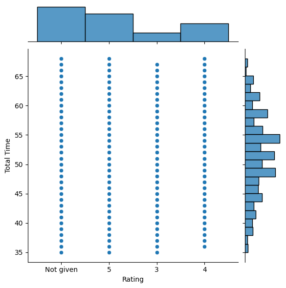

```python
#comparing total time and rating.
plt.figure(figsize=(15, 5));
df['total_time'] = df['food_preparation_time'] + df['delivery_time']

sns.jointplot(x='rating', y='total_time', data=df);
plt.ylabel('Total Time');
plt.xlabel('Rating');
```

# Most Revenue to Least Revenue

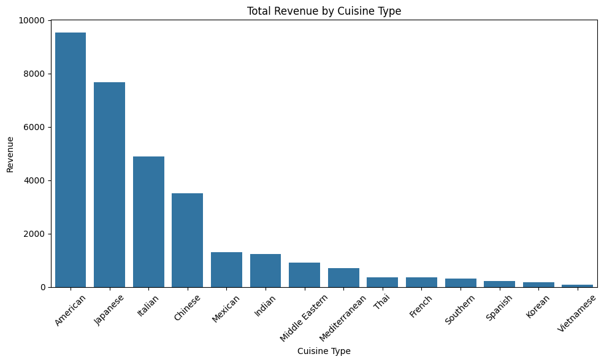

```python
# Group by 'cuisine_type' and sum 'cost_of_the_order' to get the total revenue
revenue_by_cuisine = df.groupby('cuisine_type')['cost_of_the_order'].sum().reset_index()
# Sort the values by revenue
revenue_by_cuisine_sorted = revenue_by_cuisine.sort_values(by='cost_of_the_order', ascending=False)
# Create the bar plot
plt.figure(figsize=(10, 6))
sns.barplot(data=revenue_by_cuisine_sorted, x='cuisine_type', y='cost_of_the_order')
# Set the titles and labels
plt.title('Total Revenue by Cuisine Type')
plt.xlabel('Cuisine Type')
plt.ylabel('Revenue')
# Rotate the x-axis labels for better readability
plt.xticks(rotation=45)
# Show the plot
plt.tight_layout()
plt.show()
```

# Top 10 Most Revenue Generated Restaurants

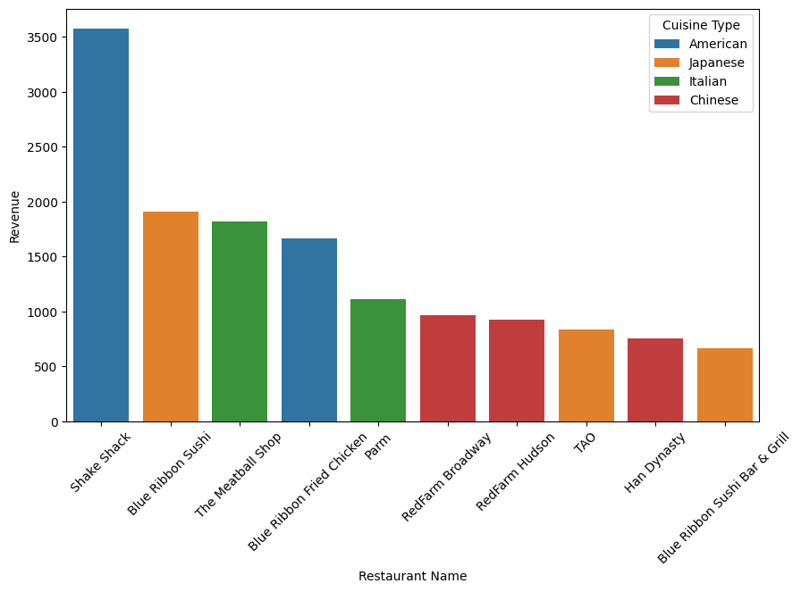

```python
# Group by 'restaurant_name' and 'cuisine_type', then sum 'cost_of_the_order'
revenue_cuisine = df.groupby(['restaurant_name', 'cuisine_type'])['cost_of_the_order'].sum().reset_index()

# Sort the values by revenue and get the top 10
most_revenue_restaurants = revenue_cuisine.sort_values(by='cost_of_the_order', ascending=False).head(10)

# Now create the bar plot with 'cuisine_type' as the hue
plt.figure(figsize=(10, 6))
sns.barplot(data=most_revenue_restaurants, x='restaurant_name', y='cost_of_the_order', hue='cuisine_type')
plt.xticks(rotation=45)
plt.xlabel('Restaurant Name')
plt.ylabel('Revenue')
plt.legend(title='Cuisine Type')
plt.show()
```

# Overall Observations:

### **Question 13:** The company wants to provide a promotional offer in the advertisement of the restaurants. The condition to get the offer is that the restaurants must have a rating count of more than 50 and the average rating should be greater than 4. Find the restaurants fulfilling the criteria to get the promotional offer. [3 marks]

```python
# Remove rows that has the rating as 'Not given'
df_rating_present = df[df['rating']!='Not given'].copy()
# Convert the string rating to numeric
df_rating_present.loc[:, 'rating'] = pd.to_numeric(df_rating_present['rating'])
# group by restaurant_name and aggregate the rating.
restaurant_ratings = df_rating_present.groupby('restaurant_name')['rating'].agg(['count', 'mean'])

# Filter out the restaurants with a rating count of more than 50 and an average rating greater than 4.
eligible_restaurants = restaurant_ratings[(restaurant_ratings['count']>50) & (restaurant_ratings['mean']>4)]

print(eligible_restaurants)
```

```
                           count      mean
restaurant_name
Blue Ribbon Fried Chicken     64  4.328125
Blue Ribbon Sushi             73  4.219178
Shake Shack                  133  4.278195
The Meatball Shop             84  4.511905
```

#### Observations:

PROMO OFFER RESTAURANTS

- Blue Ribbon Fried Chicken
- Blue Ribbon Shushi
- Shake Shack
- The Meatball Shop

### **Question 14:** The company charges the restaurant 25% on the orders having cost greater than 20 dollars and 15% on the orders having cost greater than 5 dollars. Find the net revenue generated by the company across all orders. [3 marks]

```python
# Define a method to calculate the commission.
def calculate_commission(cost):
  if cost>20:
    return round(cost*0.25,2)
  elif cost>5:
    return round(cost*0.15,2)
  else:
    return 0.00

# Apply the function to the cost of the order to find the company revenue through commission
df['commission'] = df['cost_of_the_order'].apply(calculate_commission)

# Calculate the total revenue
print("Total revenue of orders over 20:", df[df['cost_of_the_order']>20]['commission'].sum())
print('Total revenue of orders more than 5 and less than or equal to 20:', df[(df['cost_of_the_order']>5) & (df['cost_of_the_order']<=20)]['commission'].sum())
print('Total revnue:',df['commission'].sum())
```

```
Total revenue of orders over 20: 3688.88
Total revenue of orders more than 5 and less than or equal to 20: 2477.62
Total revnue: 6166.5
```

#### Observations:

- Total revenue of orders over 20: 3688.88
- Total revenue of orders more than 5 and less than or equal to 20: 2477.62
- Total revnue: 6166.5

### **Question 15:** The company wants to analyze the total time required to deliver the food. What percentage of orders take more than 60 minutes to get delivered from the time the order is placed? (The food has to be prepared and then delivered.) [2 marks]

```python
# calculate the total time and create a new column
df['total_time'] = df['food_preparation_time']+df['delivery_time']

# Find the orders that takes more than 60 mins.
round((df[df['total_time']>60].shape[0] / df.shape[0])*100,2)
```

```
10.54
```

#### Observations:

- 10.54% of orders have a total delivery time exceeding 60 minutes.

### **Question 16:** The company wants to analyze the delivery time of the orders on weekdays and weekends. How does the mean delivery time vary during weekdays and weekends? [2 marks]

```python
weekday_mean_delivery_time = df[df['day_of_the_week']=='Weekday']['delivery_time'].mean()
weekend_mean_delivery_time = df[df['day_of_the_week']=='Weekend']['delivery_time'].mean()

print('Week day mean delivery time', round(weekday_mean_delivery_time,2))
print('Week end mean delivery time', round(weekend_mean_delivery_time,2))
```

```
Week day mean delivery time 28.34
Week end mean delivery time 22.47
```

#### Observations:

- Weekend mean delivery time is faster, which indicates that deliveries are more efficient during the weekends.

### Conclusion and Recommendations

### **Question 17:** What are your conclusions from the analysis? What recommendations would you like to share to help improve the business? (You can use cuisine type and feedback ratings to drive your business recommendations.) [6 marks]

### Conclusions:

- A higher number of ratings are ‘Not given’.
- The top 5 restaurants feature American, Italian, and Japanese cuisine.
- There is no correlation between delivery time, preparation time, cost of the order, and ratings.
- Revenue is higher for orders that are more than 20, compared to orders between 5 and 20.
- Weekend mean delivery times are 20.72% faster than on weekdays.
- A few customers are ordering repeatedly via Foodhub.

### Recommendations:

- Encourage people to start giving ratings to gain more insight into process improvements. Perhaps the ‘Not Given’ option can be eliminated.
- Consider marketing American, Italian, and Japanese restaurants for increased revenue.
- Create a loyalty program for customers who order repeatedly.
- Analyze the restaurants that are receiving lower ratings and provide feedback on how to improve their ratings.
- Identify the root cause of orders that take longer delivery times or food preparation times and figure out a way to reduce these times for quicker delivery.